# 608: hw1

Jie Zou

2022-02-13

**Principles of Data Visualization and Introduction to ggplot2**

I have provided you with data about the 5,000 fastest growing companies in the US, as compiled by Inc. magazine. lets read this in:

```r
inc <- read.csv("https://raw.githubusercontent.com/charleyferrari/CUNY_DATA_608/master/module1/Data/inc5000_data.csv", header= TRUE)
```

And lets preview this data:

```r
head(inc)
```

|  | Rank | Name | Growth_Rate | Revenue | Industry | Employees | City | State |
| --- | --- | --- | --- | --- | --- | --- | --- | --- |
| 1 | 1 | Fuhu | 421.48 | 1.179e+08 | Consumer Products & Services | 104 | El Segundo | CA |
| 2 | 2 | FederalConference.com | 248.31 | 4.960e+07 | Government Services | 51 | Dumfries | VA |
| 3 | 3 | The HCI Group | 245.45 | 2.550e+07 | Health | 132 | Jacksonville | FL |
| 4 | 4 | Bridger | 233.08 | 1.900e+09 | Energy | 50 | Addison | TX |
| 5 | 5 | DataXu | 213.37 | 8.700e+07 | Advertising & Marketing | 220 | Boston | MA |
| 6 | 6 | MileStone Community Builders | 179.38 | 4.570e+07 | Real Estate | 63 | Austin | TX |

```r
NA
```

```r
summary(inc)
```

```
      Rank          Name            Growth_Rate
 Min.   :   1   Length:5001        Min.   :  0.340
 1st Qu.:1252   Class :character   1st Qu.:  0.770
 Median :2502   Mode  :character   Median :  1.420
 Mean   :2502                      Mean   :  4.612
 3rd Qu.:3751                      3rd Qu.:  3.290
 Max.   :5000                      Max.   :421.480

    Revenue            Industry
 Min.   :2.000e+06   Length:5001
 1st Qu.:5.100e+06   Class :character
 Median :1.090e+07   Mode  :character
 Mean   :4.822e+07
 3rd Qu.:2.860e+07
 Max.   :1.010e+10

   Employees           City              State
 Min.   :    1.0   Length:5001        Length:5001
 1st Qu.:   25.0   Class :character   Class :character
 Median :   53.0   Mode  :character   Mode  :character
 Mean   :  232.7
 3rd Qu.:  132.0
 Max.   :66803.0
 NA's   :12
```

Think a bit on what these summaries mean. Use the space below to add some more relevant non-visual exploratory information you think helps you understand this data:

```r
library(gghightlight)
```

[output not shown]

not sure which year is the data being collected, I did a little research about the top rank company. If it is around 2013, according to Wikipedia, its growth rate makes sense.

```r
# from the summary, Growth_Rate seems to have outliers

inc[1:5,]
```

|  | Rank | Name | Growth_Rate | Revenue | Industry | Employees | City | State |
| --- | --- | --- | --- | --- | --- | --- | --- | --- |
| 1 | 1 | Fuhu | 421.48 | 1.179e+08 | Consumer Products & Services | 104 | El Segundo | CA |
| 2 | 2 | FederalConference.com | 248.31 | 4.960e+07 | Government Services | 51 | Dumfries | VA |
| 3 | 3 | The HCI Group | 245.45 | 2.550e+07 | Health | 132 | Jacksonville | FL |
| 4 | 4 | Bridger | 233.08 | 1.900e+09 | Energy | 50 | Addison | TX |
| 5 | 5 | DataXu | 213.37 | 8.700e+07 | Advertising & Marketing | 220 | Boston | MA |

less than 1% of data present with NA, for the further analysis, I will decide to drop them.

```r
# from summary, Employees have missing value, take a look first to see these ranks
data <- inc %>%
  filter(!is.na(Employees))
```

Total 25 different industries in which IT service take up the most, which is the most popular one

```r
# what kind of industry is the lead of growth?

data %>%
  select(Industry) %>%
  group_by(Industry) %>%
  count(sort = T)
```

| Industry | n |
| --- | --- |
| IT Services | 732 |
| Business Products & Services | 480 |
| Advertising & Marketing | 471 |
| Health | 354 |
| Software | 341 |
| Financial Services | 260 |
| Manufacturing | 255 |
| Consumer Products & Services | 203 |
| Retail | 203 |
| Government Services | 202 |

[output cut: 15 more lines]

```r
NA
NA
```

based on extracted data, Business Products & Services has the highest revenue across states

```r
# which industry has the most annual revenue?

data %>%
  select(Industry, Revenue) %>%
  group_by(Industry) %>%
  summarize(total_revenue = sum(Revenue)) %>%
  arrange(desc(total_revenue))
```

| Industry | total_revenue |
| --- | --- |
| Business Products & Services | 26345900000 |
| IT Services | 20525000000 |
| Health | 17860100000 |
| Consumer Products & Services | 14956400000 |
| Logistics & Transportation | 14837800000 |
| Energy | 13771600000 |
| Construction | 13174300000 |
| Financial Services | 13150900000 |
| Food & Beverage | 12812500000 |
| Manufacturing | 12603600000 |

[output cut: 15 more lines]

```r
NA
NA
```

## Question 1

Create a graph that shows the distribution of companies in the dataset by State (ie how many are in each state). There are a lot of States, so consider which axis you should use. This visualization is ultimately going to be consumed on a ‘portrait’ oriented screen (ie taller than wide), which should further guide your layout choices.

```
label_key: State
```

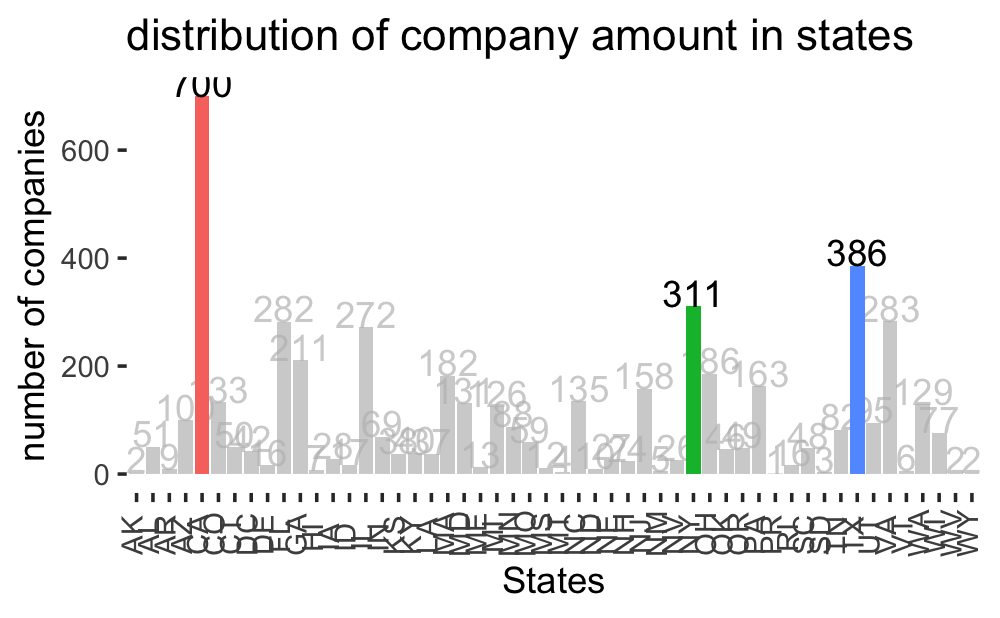

```r
states <- data %>%
  group_by(State) %>%
  select(Name, State) %>%
  count(Name) %>%
  summarize(num_comp = sum(n)) %>%
  arrange(desc(num_comp))

states %>%
  ggplot(aes(x = State, y = num_comp, fill = State)) +
  geom_bar(stat = 'identity') +
  geom_text(aes(label = num_comp), vjust = 0) +
  theme(panel.background = element_blank(),
        axis.text.x = element_text(angle = 90, vjust = 0.3, hjust = 0.3)) +
  gghighlight(State == 'CA' | State == 'TX' | State == 'NY') +
  labs(x = 'States',
       y = 'number of companies',
       title = 'distribution of company amount in states')
```

```r
NA
```

## Quesiton 2

Lets dig in on the state with the 3rd most companies in the data set. Imagine you work for the state and are interested in how many people are employed by companies in different industries. Create a plot that shows the average and/or median employment by industry for companies in this state (only use cases with full data, use R’s `complete.cases()` function.) In addition to this, your graph should show how variable the ranges are, and you should deal with outliers.

[figure not shown]

```r
# subset data only contains NY
ny <- data %>%
  filter(State == 'NY') %>%
  filter(complete.cases(.))

ny %>%
  select(Industry, Employees) %>%
  ggplot(aes(x = Industry, y = Employees)) +
  geom_boxplot() +
  scale_y_log10() +
  coord_flip() +
  theme(panel.background = element_blank()) +
  labs(x = 'Industry (by median)',
       y = 'log(Employees)',
       title = 'NY employees by different industry')
```

## Question 3

Now imagine you work for an investor and want to see which industries generate the most revenue per employee. Create a chart that makes this information clear. Once again, the distribution per industry should be shown.

```
label_key: Industry
```

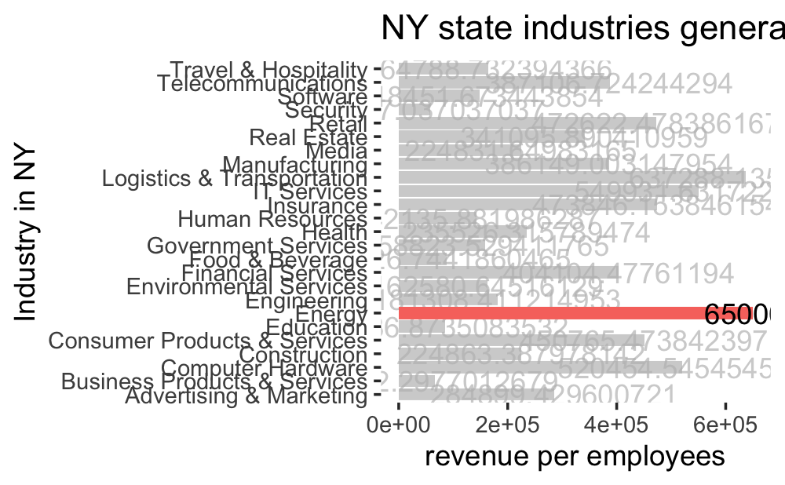

```r
inv %>%
  ggplot(aes(x = Industry, y = rev_per_emp, fill = Industry)) +
  geom_bar(stat = 'identity') +
  theme(panel.background = element_blank()) +
  geom_text(aes(label = rev_per_emp)) +
  coord_flip() +
  gghighlight(rev_per_emp == max(inv$rev_per_emp)) +
  labs(x = 'Industry in NY',
       y = 'revenue per employees',
       title = 'NY state industries generate revernue per employees')
```